# Trust in Autonomous Human-Robot Collaboration: Effects of Responsive Interaction Policies

Authors

Affiliation

Shauna Heron

Laurentian University

Meng Cheng Lau

Laurentian University

# Trust in Autonomous Human-Robot Collaboration

## Effects of Responsive Interaction Policies

**Shauna Heron & Meng Cheng Lau** School of Social Sciences, Laurentian University *An In-Person Pilot Study*

### 🎯 Research Question

**Can responsive interaction policies increase trust in fully autonomous human-robot collaboration?**

### Background

- Trust is critical for human-robot collaboration
- Most HRI/HRC studies use **Wizard-of-Oz** control or scripted interactions
- Real autonomous systems face:
  - Speech recognition errors
  - Delayed responses
  - Misinterpretations
  - Communication breakdowns

**This study:** Examined trust in HRC under **fully autonomous** affect-adaptive spoken dialogue

### Method

**Participants:** N = 29 (24 eligible)

**Robot Platform:** Misty II

- Autonomous AI dialogue (Gemini)
- Emotion detection (DistilRoBERTa)
- Real-time affect inference

**Design:** Between-subjects

- **Responsive Policy:** Proactive, affect-adaptive assistance
- **Control Policy:** Reactive, task-focused responses

**Tasks:**

1. Robot-dependent suspect identification (5 min)
2. Optional-collaboration location puzzle (10 min)

**Measures:**

- Trust Perception Scale-HRI (TPS-HRI)
- Trust in Industrial HRC (TI-HRC)
- Task accuracy
- Dialogue coding (interaction quality)

[figure not shown]

Experimental Setup

### 📊 Key Results

#### Main Finding: Responsive Policy Increased Trust in HRI

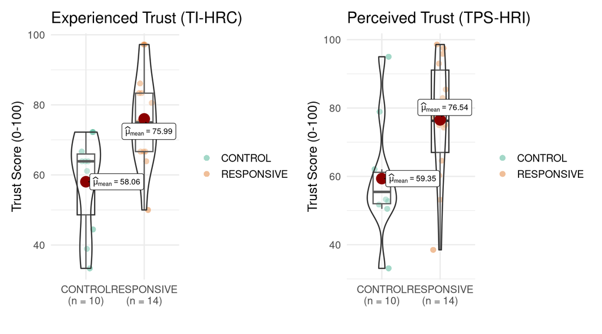

#### Task Performance: No Significant Difference

Task Accuracy by Condition & Trust

| Robot Policy | Overall Accuracy | Experienced Trust (TI-HRC) | Perceived Trust (TPS-HRI) |
| --- | --- | --- | --- |
| CONTROL | 60%<sup>1</sup> | 58.1 | 59.4 |
| RESPONSIVE | 66%<sup>1</sup> | 76.0 | 76.5 |

<sup>1</sup> No significant difference in task accuracy between conditions

**Trust appears shaped by interaction process, not necessarily task outcomes**

#### Interaction Policy Manipulation Check

Dialogue Characteristics (% of turns)

| Robot Policy | Robot Encouragement | Robot Empathy | Collaborative Language | Communication Breakdown |
| --- | --- | --- | --- | --- |
| CONTROL | 0%<sup>1</sup> | 0%<sup>1</sup> | 5%<sup>1</sup> | 12% |
| RESPONSIVE | 36%<sup>1</sup> | 13%<sup>1</sup> | 42%<sup>1</sup> | 11% |

<sup>1</sup> Responsive policy generated significantly more encouragement, empathy, and collaborative language. A turn is defined as a single utterance/response diad.

Experienced trust (TI-HRC):

- *I trusted that the robot would give me accurate answers*
- *The way the robot moved made me uneasy*

Perceived trust (TPS-HRI):

- *What percent of the time was the robot reliable?*
- *What percent of the time was the robot trustworthy?*

Human Dialogue Characteristics (% of human turns)

| Robot Policy | Anthropomorhpic Language | Engagement Detected | Frustration Detected | Reasoning With Robot | Turns Engaged Robot for Help |
| --- | --- | --- | --- | --- | --- |
| CONTROL | 4%<sup>1</sup> | 13%<sup>1</sup> | 4%<sup>1</sup> | 52% | 76% |
| RESPONSIVE | 10%<sup>1</sup> | 25%<sup>1</sup> | 6%<sup>1</sup> | 70% | 73% |

### 💡 Key Insights

#### 1. Process > Outcomes

Trust formed through **interaction quality** and **affective responsiveness**, not task success alone

#### 2. Differential Sensitivity

**Affective trust** more sensitive to communication breakdown than **reliability judgments**

#### 3. Communication Viability Matters

Responsive policy benefits require **functional linguistic grounding**

When communication collapsed:

- Trust advantage attenuated
- Ratings less interpretable

#### 4. Real Autonomy = Real Constraints

Fully autonomous systems expose:

- Speech recognition failures
- Repair dynamics
- Interaction breakdowns

**These failures shape trust formation**

### 🔬 Novel Contributions

✓ **Fully autonomous affect-adaptive spoken-language HRI study** ✓ **No Wizard-of-Oz control** ✓ **Real-time emotion detection & adaptation** ✓ **Process-level trust mechanisms identified**

### 📈 Implications

**For HRI Design:**

- Responsive policies enhance trust under viable communication
- Communication quality is prerequisite, not just moderator
- Need adaptive policies that detect/respond to breakdown

**For Research:**

- Importance of testing under real autonomy
- Trust is process-level, not just outcome-level
- Communication viability must be measured/reported

### 🔮 Future Directions

- Larger confirmatory sample (n > 100)
- Stabilize speech recognition pipeline
- Graph-based dialogue management
- Adaptive language handling
- Stronger trust measures

### 📧 Contact

**Shauna Heron** sheron@laurentian.ca

**Funding:** IAMGOLD President’s Innovation Fund

**Key Takeaway:** AI-based affect-adaptive robots may increase trust through responsive interaction processes, even when task performance is unchanged; but only when communication remains viable.